# Ch3_homework_2016-09-20

## Hard problems; boys are 1, girls are 0

```r
birth1 <- c(1,0,0,0,1,1,0,1,0,1,0,0,1,1,0,1,1,0,0,0,1,0,0,0,1,0,
0,0,0,1,1,1,0,1,0,1,1,1,0,1,0,1,1,0,1,0,0,1,1,0,1,0,0,0,0,0,0,0,
1,1,0,1,0,0,1,0,0,0,1,0,0,1,1,1,1,0,1,0,1,1,1,1,1,0,0,1,0,1,1,0,
1,0,1,1,1,0,1,1,1,1)
birth2 <- c(0,1,0,1,0,1,1,1,0,0,1,1,1,1,1,0,0,1,1,1,0,0,1,1,1,0,
1,1,1,0,1,1,1,0,1,0,0,1,1,1,1,0,0,1,0,1,1,1,1,1,1,1,1,1,1,1,1,1,
1,1,1,0,1,1,0,1,1,0,1,1,1,0,0,0,0,0,0,1,0,0,0,1,1,0,0,1,0,0,1,1,
0,0,0,1,1,1,0,0,0,0)
library(rethinking)
data(homeworkch3)

# total number of boys
sum(birth1) + sum(birth2)
```

```
## [1] 111
```

## 3H1

Using grid approximation, compute the posterior distribution for the probability of a birth being a boy. Assume a uniform prior probability. Which parameter value maximizes the posterior probability?

I think that this is over the entire dataset, or 200 trials.

```r
p_grid.h1 <- seq( from=0 , to=1 , length.out=1000 )
prior.h1 <- rep( 1, 1000)

# first, for 111 boys in 200 births
likelihood.h1 <- dbinom( 111, size=200 , prob=p_grid.h1 )
posterior.h1 <- likelihood.h1 * prior.h1
posterior.h1 <- posterior.h1 / sum(posterior.h1)

# and max value would be
p_grid[ which.max(posterior.h1) ]  # 0.5545546
```

```
## [1] 0.5545546
```

## 3H2

Using the sample function, draw 10,000 random parameter values from the posterior distribution you calculated above. Use these samples to estimate the 50%, 89%, and 97% highest posterior density intervals.

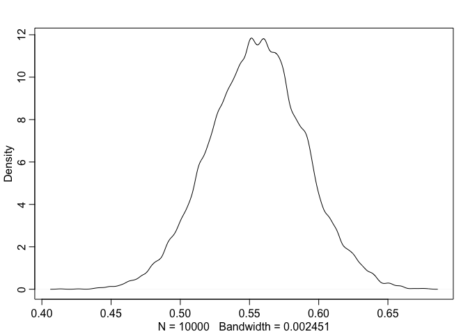

```r
#Draw 10,000 samples from the grid approximation from above. Then use the samples to calculate the 50%, 89%, and 97% for p
set.seed(100)

samples.h1 <- sample( p_grid.h1 , prob=posterior.h1 , size=1e4 , replace=TRUE )

dens(samples.h1) # looks good
```

```r
HPDI(samples.h1, prob = 0.5)  # 0.53 to  0.57
```

```
##      |0.5      0.5|
## 0.5315315 0.5765766
```

```r
HPDI(samples.h1, prob = 0.89)  # 0.50 to  0.61
```

```
##     |0.89     0.89|
## 0.4974975 0.6076076
```

```r
HPDI(samples.h1, prob = 0.97)  # 0.48 to  0.63
```

```
##     |0.97     0.97|
## 0.4774775 0.6276276
```

## 3H3

Use rbinom to simulate 10,000 replicates of 200 births. You should end up with 10,000 numbers,each one a count of boys out of 200 births. Compare the distribution of predicted numbers of boys to the actual count in the data (111 boys out of 200 births). There are many good ways to visualize the simulations, but the dens command (part of the rethinking package) is probably the easiest way in this case. Does it look like the model fits the data well? That is, does the distribution of predictions include the actual observation as a central, likely outcome?

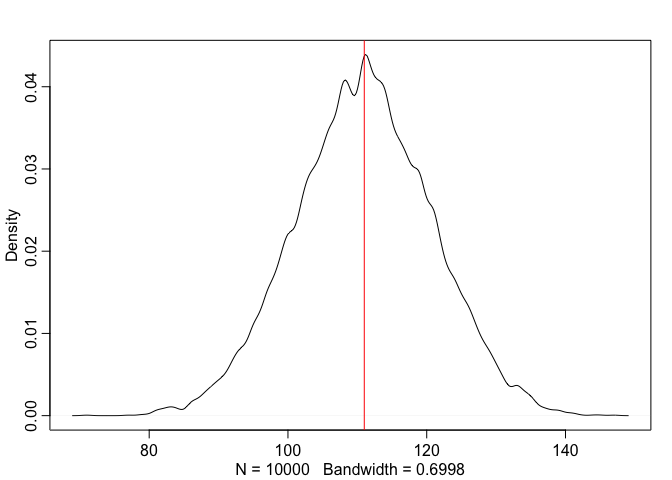

```r
sim.3h3 <- rbinom( 1e4 , size=200 , prob=samples.h1 )
dens(sim.3h3)
abline(v=111, col = "red")
```

that looks pretty good.